# Lecture 2: Cryptographic hash functions

### Announcements

- *Please pick up a card and write your name + BU ID on the back*
- Reading Assessment 1 due on Friday 9/12 on Gradescope, covering [PPG section 1.1](https://ezproxy.bu.edu/login?url=https://link.springer.com/content/pdf/10.1007/978-3-662-69007-9_13) and [NBFMG section 1.1](https://d28rh4a8wq0iu5.cloudfront.net/bitcointech/readings/princeton_bitcoin_book.pdf)
- Homework 1 due on Friday 9/12 on Gradescope
- Office hours: no office hours on Monday, will start office hours on Tuesday

### Interactive questions

Lectures in this class contain interactive multiple-choice questions. You must display your card with the intended response side facing up, and without covering the QR code.

*Privacy note:* neither I nor the plickers.com website save any pictures of students. All camera processing takes place on my phone, and only your QR code results are sent to the website.

Let’s try an example.

**Interactive question.** How would you rate this course so far?

1. Amazing!
2. Excellent!
3. Great!
4. Superb!

### Learning outcomes

By the end of today’s lecture, you will learn:

- The security guarantees of hash functions: one-wayness, collision resistance, and acting as a random oracle.
- How the one-wayness and collision resistance of a hash function depends on its output length, and why cryptographers are satisfied with output lengths like $n = 256$ bits.
- How hash functions can be used to authenticate (sets of) files.

### Review from last week

> “Cryptography is how people get things done when they need one another, don’t fully trust one another, and have adversaries actively trying to screw things up.”

> – Ben Adida

Cryptography uses math, computer science, and data science to design systems that help people to get things done safely in the digital world.

- **C**onfidentiality: hiding data
- **I**ntegrity: preventing or detecting tampering of data
- **A**vailability: preventing censorship of data

Computers represent data in *bits* and *bytes*. We can observe this data in many formats like binary, int, hex, and base64. As we will see today, cryptographic tools can be very precise when considering *how* data is represented.

The cryptographic tools we will design over the course of the semester fall into two categories:

- Elegant **protocols** that accomplish tasks that people want
- Utilitarian **primitives** that achieve concrete mathematical security objectives

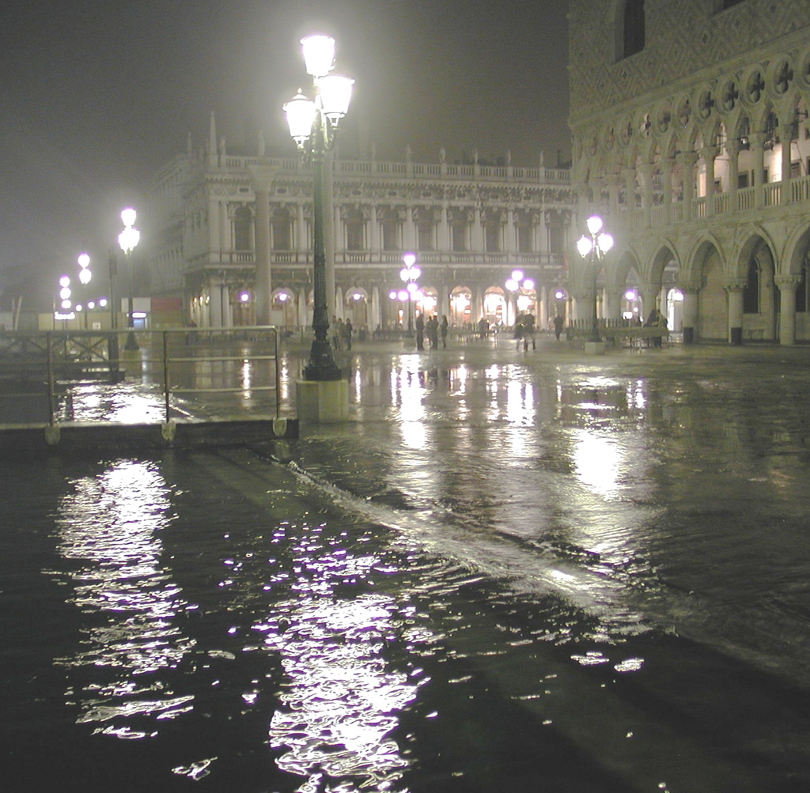

City of Venice, Italy (source: [Wikipedia](https://commons.wikimedia.org/wiki/File:Venezia_acqua_alta_notte_2005_modificata.jpg))

## 2.1 Digital fingerprinting

Today, we will study a special function – called a **cryptographic hash function** – that is used as a building block within many crypto primitives and protocols.

To motivate today’s discussion, let’s consider the following problem:

- Alice wants to store a large file $x$ on a cloud service like Dropbox or Google Drive.
- When she retrieves it later, Alice wants to be able to verify that the file hasn’t been altered or corrupted on the cloud.

Alice

Cloud service

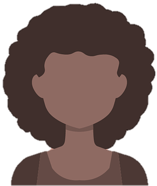

$\quad \Longleftrightarrow \quad$

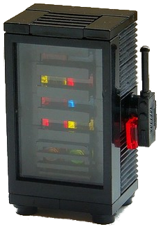

**Question.** Can we design the cloud storage service in a way that guarantees **integrity** to Alice? Specifically, Alice wants to be convinced that the cloud service provider is not cheating when revealing $x$.

What would be great is if there was a function $H$ that we could apply to the file $x$ that:

- Can act as a “fingerprint,” in the sense that it uniquely specifies the file.
- Produces a small output, so that it’s easy for Alice to save $H(x)$ on her computer, even if the entire file $x$ is too large to save.

Producing a small output of size $n$ is easy to do. We could:

- Truncate the file and keep just the first $n$ bits,
- Add together all length-$n$ chunks of the file,
- Apply a linear transformation to the file
- …and much more.

**Question.** What could go wrong with these functions?

**Answer.** All of them allow the cloud provider to cheat by revealing a different file with the same $n$-bit prefix, or sum, or image after the linear transformation.

Depending on the file type and format, it might be the case that we get lucky. For instance, maybe $x$ is the only file in the world that maps to the fingerprint $H(x)$.

But in cryptography, we are not in the business of relying on luck. Instead, let’s make our own luck.

### Collision resistance

Recall that our goal is to “compress” a large image $x$ into a small (say, constant-sized) output $y = H(x)$ while making sure that Alice doesn’t change the image afterward.

Because $H$ has infinitely many inputs and only finitely many outputs, it must be the case that there are **collisions** – that is, two inputs that map to the same output string.

But: we are going to insist that *collisions are computationally infeasible to find*. This guarantee should hold even if we give the code of $H$ to our adversary. This property is called **collision resistance**.

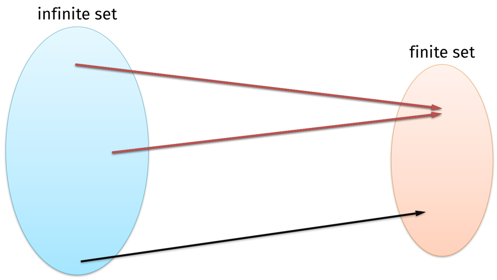

### Meet Mallory

Here is our adversary in this course. Her name is Mallory, because she is *malicious* and doesn’t follow the rules of any crypto protocol.

Mallory is intended to be a stand-in for any kind of real-world adversary who you might be concerned about: your cloud provider, internet service provider, government, or anyone else who might want to ruin your day.

- Mallory has a substantial (though not infinite) amount of computing power at her disposal.
- Mallory is also very smart. Specifically, we must assume that she is a better cryptanalyst than we are. This is to account for **Schneier’s law**.

> “Anyone, from the most clueless amateur to the best cryptographer, can create an algorithm that he himself can’t break.”

> – Bruce Schneier

Even though Mallory is mathematically savvy and computationally powerful, we insist that she must still not be able to “break” our function $H$.

## 2.2 Cryptographic hashing

> Often called a **cryptographer’s Swiss Army knife**, a hash function can underlie many different cryptographic schemes: aside from producing a document’s digest to be digitally signed—one of the most common applications.

> Let us give example applications: code-signing systems, computer forensics, [and protecting] passwords.

> – Aumasson, Meier, Phan, and Henzen, *The Hash Function BLAKE*.

[figure not shown]

Swiss Army knife

A cryptographic hash function, which we typically denote by $H$, has two seemingly-contradictory requirements.

- It should be **public** and **deterministic**, so everyone can compute it quickly, and yet
- It should be **unpredictable** and **random-looking**, so that nobody can understand how its outputs are connected to its inputs.

You can think of a hash function as a gigantic function that translates between two languages:

- The inputs that have some mathematical or English-language structure that makes sense to us.
- The outputs are a new kind of “foreign language” that is incomprehensible to all of us on Earth.

[figure not shown]

Klingon-to-English dictionary ([image source](https://www.simonandschuster.com/books/The-Klingon-Dictionary/Marc-Okrand/Star-Trek/9780671745592))

Moreover, the outputs have a fixed, known length, no matter how short or long the input messages are. As a toy example: the follow truth table was produced by mapping the [top 3000 English words](https://www.britannica.com/dictionary/eb/3000-words/alpha/a) to random 4-letter strings using [random.org](https://www.random.org/strings/).

| Input | Output |
| --- | --- |
| abandon | `nieh` |
| ability | `btol` |
| able | `ykwf` |
| about | `fkay` |
| $\vdots$ | $\vdots$ |
| zipper | `jgxm` |
| zone | `pnjo` |
| zoo | `ansm` |

While this toy example used English-language words as the possible inputs, in reality we want a hash function to accept any data type. To be as generic as possible, we will consider the inputs and outputs to be `bitstrings`. Then, we can apply $H$ to Alice’s file, in any data format.

### Defining hash functions

Whenever we study a new crypto primitive in this course, I will define precisely its API. A cryptographic hash has a simple interface.

**Definition 1 (Cryptographic hash function)** A *hash function* $H: \{0, 1\}^* \to \{0, 1\}^n$ is an efficiently-computable function that

- Receives an input bitstring of arbitrary length, and
- Provides an output bitstring that contains a fixed number of bits $n$.

Note that there is nothing hidden or secret here: the *code of $H$ is public knowledge* and anyone can compute it.

The output $H(x)$ is often called the **hash digest** corresponding to the input $x$.

For example, here is some Python code for a popular cryptographic hash function called **SHA-256**, which has an output length of 256 bits.

```python
# install PyNaCl with "pip install pynacl"
import nacl.hash
sha256 = lambda message: nacl.hash.sha256(message, encoder=nacl.encoding.HexEncoder)

hexDigest = sha256(b'Hello world!')
print(hexDigest)
```

```
b'c0535e4be2b79ffd93291305436bf889314e4a3faec05ecffcbb7df31ad9e51a'
```

A hash function is deterministic: if you feed in the same input twice, you will get the same output twice.

```python
print(sha256(b'Hello world!'))
```

```
b'c0535e4be2b79ffd93291305436bf889314e4a3faec05ecffcbb7df31ad9e51a'
```

Small changes to the input of the hash function cause substantial changes to the output.

```python
message = b'Hello world?'
print(sha256(message))
```

```
b'43f497ee7ac09843d631362ef9aca26a0cab437acaea8a98e44afa7ad65a2d41'
```

Taking the hash of a message vs. the hex-encoding of a message produces *very* different results!

```python
from binascii import hexlify
hexMessage = hexlify(message)

print(sha256(hexMessage))
```

```
b'9c55c598e927c2ba0096d166f39c539cad2b0a3210dadf81a5bc9638681af1d5'
```

For this reason, I recommend using variable names that explicitly identify whether a variable contains raw bytes or a hex encoding.

As the name suggests, SHA-256 has an output length of 256 bits, or 32 bytes. This is represented using 64 hex characters, since each hex character encodes 4 bits of data.

```python
print(len(hexDigest))
```

```
64
```

The input to the hash function can be any size. No matter what: the output is always 256 bits long.

```python
print(len(sha256(b'A')))
print(len(sha256(b'It was the best of times, it was the worst of times, it was the age of wisdom, it was the age of foolishness, it was the epoch of belief, it was the epoch of incredulity, it was the season of light, it was the season of darkness, it was the spring of hope, it was the winter of despair.')))
```

```
64
64
```

### Security of hash functions

Next, we need to specify precisely the problem that Mallory cannot break. In fact we will define multiple such problems. As we go down the list:

- The problems become easier and easier to break, so$\ldots$
- If Mallory still cannot break them, then the hash function $H$ must be really strong.

**Definition 2 (Hash function requirements)** A cryptographic hash function $H$ achieves the following security properties.

- **One-wayness**, aka **preimage resistance**: if we sample $y \gets \{0, 1\}^n$ uniformly at random from the set of all bitstrings of length $n$, then it is practically infeasible for Mallory to find any preimage $x$ such that $H(x) = y$. (Remember that there are *infinitely* many such preimages. Still though, we insist that Mallory cannot find even a single one!)
- **Collision resistance**: it is practically infeasible for Mallory to find two different inputs $x_1$ and $x_2$ such that $H(x) = H(x')$.

  (Note: if a function is collision resistant then it must be one-way, but the converse is not necessarily true. Think about why that is?)
- **Puzzle friendliness**: (this property is complicated to describe; we will come back to it later)
- **Random oracle**: $H$ acts like a randomly-generated truth table would.

> If an adversary [Mallory] has not explicitly queried the oracle on some point $x$, then the value of $H(x)$ is completely random… at least as far as [Mallory] is concerned.

> – Jon Katz and Yehuda Lindell, *Introduction to Modern Cryptography*

**Interactive Question.** Which security requirement of a cryptographic hash function ensures that no one can *invert* the output of a hash function to recover a corresponding input?

1. Pre-image resistance
2. Collision resistance
3. Puzzle friendliness
4. Random oracle

Note that there is a limit to *how* infeasible it is to find a collision.

- As we already said, collisions must exist!
- And the output space is finite.

So if Mallory has enough time and computing power, it must be possible to find a collision.

Exactly how difficult can we hope that the problem might be? That is, even with the *best possible* hash function, what is a blunt and **brute force attack** that will always succeed?

## 2.3 The birthday problem

Let’s step away from hash functions for a moment, and look at a seemingly-unrelated question. Let $K$ be the number of people in this classroom.

**Interactive Question.** Approximately what is the probability that two people in this room have the same birthday?

1. Rare (around 10%)
2. Possible but unlikely (around 30%)
3. Chances about even (around 50%)
4. Probable (70% or more)

(For the purpose of this question, suppose that everyone’s birthday is sampled uniformly at random from the set of 366 possible choices. This is not a valid assumption for many reasons, e.g., leap years, but let’s go with it for now.)

### The paradox

It might intuitively seem like the answer should be $\frac{K}{366}$.

But that is incorrect! It would be the answer to a different problem:

> What is the probability that *at least one* of $K$ students in this classroom has the same birthday *as Prof. Varia* does?

The distinction between these two questions (and their corresponding answers) is called the **birthday paradox**.

### Thinking about pairs

The answer to the original question depends on the number of *pairs* of people in the classroom.

- If birthdays are sampled uniformly at random, each pair has a $\frac{1}{366}$ chance of having the same birthday.
- There are $K \choose 2$ pairs of people in the room.

So the answer to the question is closer to ${K \choose 2} / 366 \approx K^2 / (2 \cdot 366)$ than it is to $K / 366$.

But ${K \choose 2} / 366$ is not exactly right either. The reason is the *principle of inclusion-exclusion*: we would be overcounting in scenarios where many people have the same birthday.

### The math

Instead, it is easier to think about the opposite problem. Suppose $K = 23$, and let’s imagine that the $K$ people walk into the classroom, one at a time.

What is the probability that all of them have *different* birthdays?

- The first person certainly has a different birthday than everyone else in the room (since there is nobody else in the room yet).
- The second person has probability 365/366 of having a different birthday than the first person.
- Conditioned on the first two people having distinct birthdays, the third person has probability 364/366 of having a different birthday than both of them.
- …and so on, until the 23th person to enter the room has a 344/366 probability of having a birthday that is different than the other 22 people already in the room.

$$1 \times \frac{365}{366} \times \frac{364}{366} \times \cdots \times \frac{344}{366}$$

We can calculate this expression using Python.

```python
import math
math.prod(range(344,367)) / (366**23)
```

```
0.49367698818054007
```

The punchline is: if there are 23 people in the classroom, then it is more likely than not that two of us have the same birthday!

Here’s a graph that shows the probability of two people having the same birthday in a room of $K$ people.

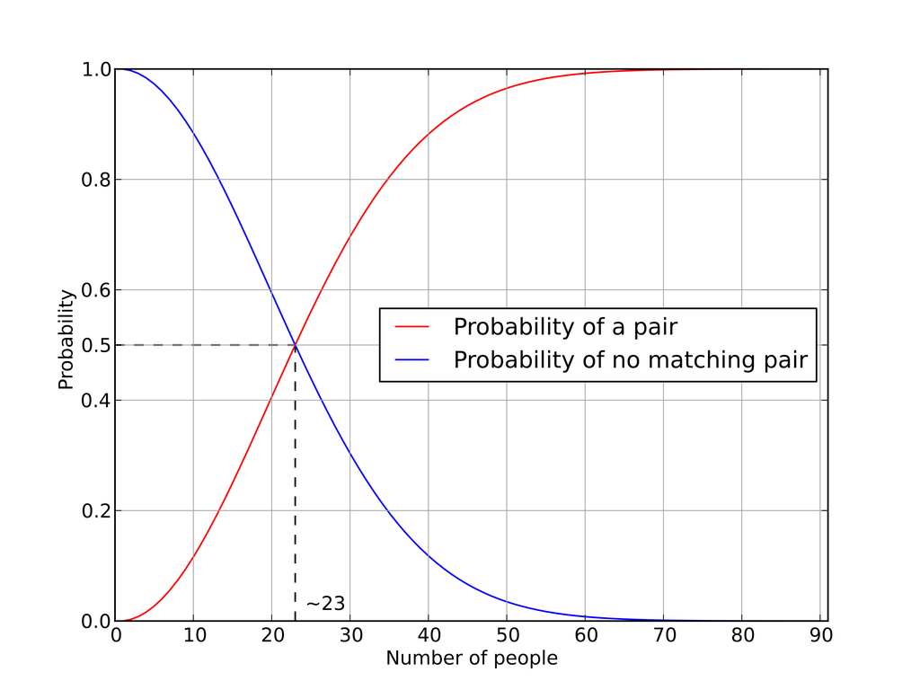

Birthday paradox

Generalizing from the specific case of birthdays (where there are $N = 366$ options): when drawing with replacement from a set of size $N$, then:

$$E[\text{\# of attempts until the first collision}] \approx 1.25 \sqrt{N}.$$

This approximation works well even for fairly small choices of $N$, such as $N = 366$. And it works really well for larger $N$.

```python
import math
1.25 * math.sqrt(366)
```

```
23.91390808713624
```

## 2.4 Back to hash functions

The key insight from the birthday problem is that:

> The best-possible security that we can hope for a hash function $H: \{0, 1\}^* \to \{0, 1\}^n$ to achieve is related to the **length of the output space $n$**.

**Example.** Suppose that we build a hash function whose output length is $n = 3$ bits. Let’s try to break one-wayness and collision resistance using a simple guess-and-check approach.

To break one-wayness for (say) $y = 000$, suppose we just select inputs $x$ at random and compute the hash function until we find an input where $H(x) = y$.

- Each sample of $x$ will satisfy the equation with probability 1/8.
- So in expectation, we will find an input $x$ such that $H(x) = y$ after 8 attempts.
- There is a chance that we get unlucky and it could take much longer. Probabilistically: the number of attempts until the first success follows the distribution of a *geometric random variable*.

Now let’s try to break collision resistance. Once again, suppose that we aimlessly select inputs $x$ at random and build a table of all $(x, H(x))$ pairs until we find two inputs with the same digest.

- In the worst case, we can select 9 inputs, and by the *pigeonhole principle* two of them must map to the same output.
- In expectation, the birthday bound says that the expected number of trials is around $1.25 \cdot \sqrt{2^n} \approx 4$.

### Choosing larger $n$

So in order to have a secure hash function, it is necessary (though not sufficient) to choose a large number of possible outputs $N$. A common choice in cryptography is to choose an output length of $n = 256$ bits, so that $N = 2^{256}$.

Extrapolating from the analysis above, our **brute-force attack** succeeds at breaking:

- One-wayness with good probability by an attacker who tries around $2^{256}$ inputs.
- Collision resistance with good probability by an attacker who tries around $\sqrt{2^{256}} = 2^{128}$ inputs.

These are both **big** numbers.

- In fact, both of them are so big as to be practically impossible for anyone to execute, with the computing power available today or in the near future.
- But do note that they are different scales of big-ness. Remember that $2^{256}$ is not two times as big as $2^{128}$. It is instead $2^{128}$ times as big!

### How large is $2^{128}$?

This calculation discounts the effect of Moore’s law. Nevertheless, it shows the vast computing power required to break collision resistance.

The number $2^{256}$ is much, much larger than this. As we discussed last time: even running a `for` loop over $2^{256}$ possible preimages would require (1) more time than the expected remaining length of the universe and (2) approximately as much energy as the sun.

## 2.5 Back to digital fingerprinting

So far, we have talked about the *best-possible* security that a hash function can hope to achieve.

- Good news: the crypto community has built hash functions that nobody knows how to attack faster than a birthday bound
- We’ll see some constructions in the next lecture

For today, let’s return to the outsourced cloud example from the beginning of the lecture. Recall that:

- Alice wants to store a large file $x$ on a cloud service like Dropbox or Google Drive.
- When she retrieves it later, Alice wants to be able to verify that the file hasn’t been altered or corrupted on the cloud.

**Question.** How can Alice do this?

Here is one common approach:

- Before Alice uploads $f$ to the cloud, she computes the hash digest $d = H(f)$.
- Alice stores $d$ on her computer even after uploading $f$ to the cloud. (Remember that $d$ is small, only 32 bytes in size.)
- When Alice later downloads a file $f'$, check that $H(f') \overset{?}{=} d$.

This approach is both simple and secure.

- Modern hash functions are very quick to compute, even on large files that are gigabytes in size.
- *Collision resistance* ensures that even if Mallory is running the cloud provider, she cannot find a new file $f'$ that is different from Alice’s original file $f$ and yet still hashes to the same string $h$.